# Meeting 11 Notes

Matthew Aiello-Lammens

4/22/2020

# Linear regression - recap

Flour beetle data on effects of starvation and humidity on weightloss of flour beetls

```r
flr_beetle <- read.csv(file = "https://mlammens.github.io/ENS-623-Research-Stats/data/Logan_Examples/Chapter8/Data/nelson.csv")
```

Plot these data

- response variable on the y-axis
- predictor variable on the x-axis

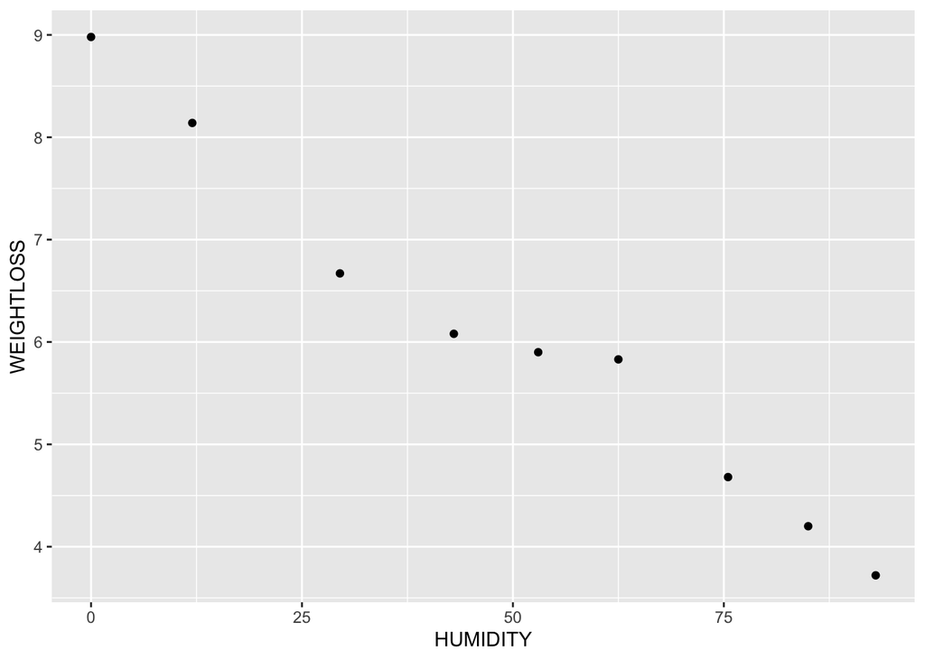

```r
library(ggplot2)
ggplot() +
  geom_point(data = flr_beetle, aes(x = HUMIDITY, y = WEIGHTLOSS))
```

Let’s do a linear regression on these data

response = left-hand side predictors = right-hand side y ~ x

y = b0 + b1*x + errors

```r
flr_beetle_lm <- lm(data = flr_beetle, WEIGHTLOSS ~ HUMIDITY)
summary(flr_beetle_lm)
```

```
##
## Call:
## lm(formula = WEIGHTLOSS ~ HUMIDITY, data = flr_beetle)
##
## Residuals:
##      Min       1Q   Median       3Q      Max
## -0.46397 -0.03437  0.01675  0.07464  0.45236
##
## Coefficients:
##              Estimate Std. Error t value Pr(>|t|)
## (Intercept)  8.704027   0.191565   45.44 6.54e-10 ***
## HUMIDITY    -0.053222   0.003256  -16.35 7.82e-07 ***
## ---
## Signif. codes:  0 '***' 0.001 '**' 0.01 '*' 0.05 '.' 0.1 ' ' 1
##
## Residual standard error: 0.2967 on 7 degrees of freedom
## Multiple R-squared:  0.9745, Adjusted R-squared:  0.9708
## F-statistic: 267.2 on 1 and 7 DF,  p-value: 7.816e-07
```

y = 8.704027 + (-0.053222) * x + error

WEIGHTLOSS = 8.704027 + (-0.053222) * HUMIDITY

R^2 = 0.9708 — > 97% of the variation observed in WEIGHTLOSS is explained by variation in HUMIDITY

- Significant interecept estimates (significantly different from 0) are almost never interesting
- Significant slope estimates (significantly different from 0) ARE interesting

Plot these data again, with a regression line added

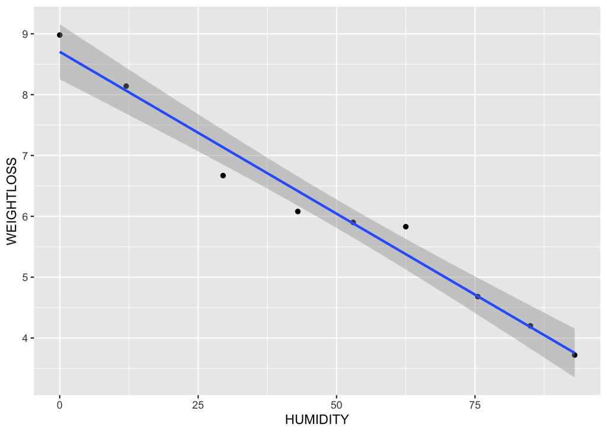

```r
ggplot(data = flr_beetle, aes(x = HUMIDITY, y = WEIGHTLOSS)) +
  geom_point() +
  geom_smooth(method = "lm")
```

# Linear regression assumptions

1. Normality - y values are normal and the residuals (error values) are approximately normal
2. Homogeneity of variance - there aren’t trends in the variance as x values change
   - Example of heterogentieity of variance = the variance observed in your y values increases as your x values increase
3. Independence - each y observation is independent and the error values are independent
   - Non-independence of error value may result from temporal or spatial autocorrelation

## Other assumptions

- Linearity - simple linear regession (i.e., fitting a straight line)
- Fixed x values - uncertainty in x is due to observation errors, but there’s no underlying uncertainty
  - Should be able to explain all variation in our predictor variables

# Line fitting

Find a line, with intercept b_0 and slope b_1, such that the line minimizes our residuals

How do we know what values our linear regression predict for our y’s (y-hat)

```r
library(dplyr)
```

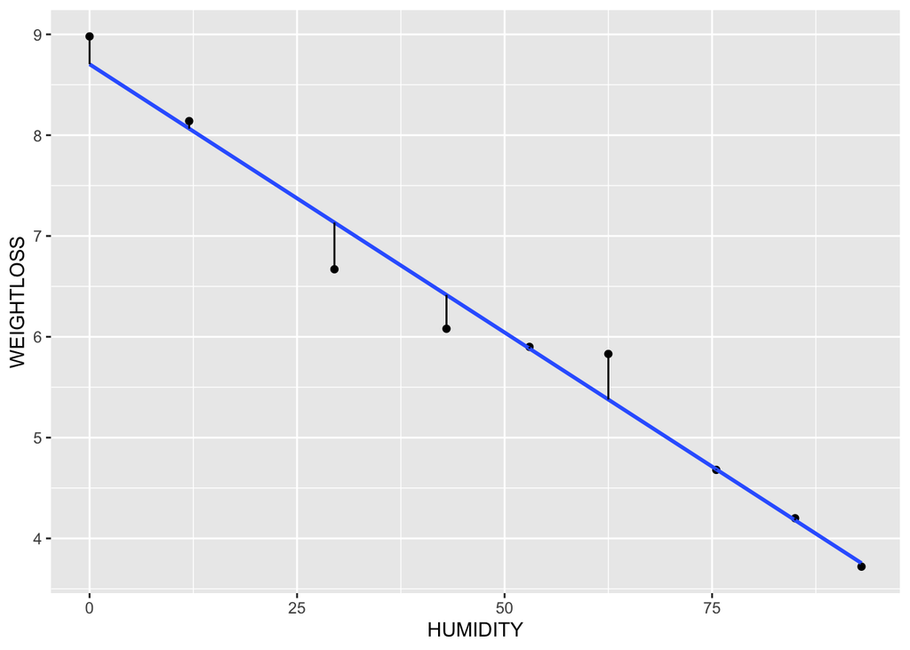

```r
flr_beetle$y_hat <- predict(flr_beetle_lm, newdata = flr_beetle)
flr_beetle$y_min <- apply(select(flr_beetle, WEIGHTLOSS, y_hat), MARGIN = 1, FUN = min)
flr_beetle$y_max <- apply(select(flr_beetle, WEIGHTLOSS, y_hat), MARGIN = 1, FUN = max)

ggplot(data = flr_beetle, aes(x = HUMIDITY, y = WEIGHTLOSS)) +
  geom_point() +
  geom_smooth(method = "lm", se = FALSE) +
  geom_linerange(aes(ymin = y_min, ymax = y_max))
```

We want to find b_0 and b_1 for the line that minimizes sum(residuals^2)

$$\sum{(y_i - \hat{y}_i)^2}$$

We call this the sum of squares residuals (sum of squares error or sum of squares deviations)

How do we find the line that minimizes the above?

- fit a line by eye, estimate the slope and y-intercept, calculate SS_res, take another guess, calculate SS_res again, and keep which ever set of slope and y-intercept values result in a smaller SS_res, repeat -> Inefficient
- principles of calculus and the equation for the probability distribution associated with linear regression (saw this last week), find values of b_0 and b_1 that minimize SS_res analytically

## My model looks good, but is it meaningful

Compare the variance that is explained by my model versus the variance that is not explained by my model.

**Your residuals represent the variance (variation) that is *not* explained!**